# S2.4: il simulatore cattura i trascritti come un vetrino vero (strisce, fondo, seconda coda)?

geo_spatialtrans, report di step (protocollo v2)

Published

November 7, 2026

# In breve

### In breve: il simulatore cattura i trascritti come un vetrino vero, con le strisce di righe e colonne, il fondo sul vetro e la coda lunga dello spostamento?

**A cosa serviva.** Questo step aggiunge al simulatore il passo che trasforma i trascritti spostati nei conteggi di un vetrino: righe e colonne della griglia catturano in modo diverso (le «strisce»), sul vetro c’è un fondo, e una piccola parte dei trascritti finisce a centinaia di micron di distanza. Abbiamo controllato che le strisce simulate siano indistinguibili da quelle vere con lo stesso stimatore, che il vetro intorno alle cinque sezioni intere sia descritto bene, e quanto costa in tempo e memoria.

**Cosa abbiamo trovato.**

1. **Le strisce simulate sono come quelle vere in tutti e sei i tessuti.**
   - Differenza fra righe pari e dispari, ampiezza dei fattori di riga e colonna, somiglianza fra righe vicine: nessuno scarto rilevante; dove l’esito resta incerto è per la precisione, non per uno scarto.
   - Lo stimatore non trova strisce quando le spegniamo: il confronto ha potere.
2. **Fondo e coda lunga, rifatti insieme come avevi scelto, descrivono il vetro di quattro sezioni su cinque a ogni distanza; nel tumore del colon solo fino a un quarto di millimetro.**
   - In intestino, linfonodo e cuore il fondo costante sparisce: tutto il vetro si spiega con una coda di trascritti che arriva a 1-2 mm (nel cuore a un decimo di millimetro).
   - Nel tumore del colon il vetro vero ha 7 decimi dei trascritti previsti fra un quarto e mezzo millimetro dal tessuto, e meno della metà oltre; lì fondo e coda si separano male.
   - La coda raddoppia i trascritti nei lumi profondi del tumore del colon, che passano da circa metà del vero a 7-9 decimi.
3. **La parte lenta delle strisce non entra nel simulatore.**
   - Sul vetro la troviamo solo in due sezioni su cinque, e il revisore ha mostrato che può essere un errore del modello del vetro più che una vera variazione della cattura. Resta un limite dichiarato.
4. **I quadratini vuoti veri non vengono dalle strisce.**
   - Nell’intestino, nel tumore e nel suo stroma il simulato ha da un decimo a quattro decimi dei quadratini vuoti veri.
5. **La memoria supera gli 8 GB del progetto in tumore, stroma e cervello, ma il rimedio c’è.**
   - Per avere conteggi interi e una verità esatta si generano da 3 a 6 volte i trascritti; il picco è nella funzione che li sposta (fino a 15-20 GB nel cervello).
   - Lavorando a blocchi più piccoli il cervello sta in 6 GB e meno di 3 minuti. Lo imposterà la funzione che metterà insieme tutti i passi.
   - Trovato e corretto anche un difetto dei generatori casuali: semi consecutivi davano estrazioni legate fra loro. Le funzioni nuove ne sono esenti; quelle dei passi precedenti vanno corrette.

**Cosa devi decidere.**

1. **Chiudiamo lo step anche se un controllo automatico è fallito come scritto? Consiglio di sì.**
   - Su 120 simulazioni, una ha catturato un numero di trascritti a 3.01 errori casuali dall’atteso, contro una soglia scritta di 3; sulle 120 è quanto ci si aspetta dal caso.
   - Alternativa: rifare il controllo con la soglia per confronti multipli che avevamo scritto in testa ai controlli; passerebbe, ma sarebbe cambiare la regola dopo il risultato.
2. **Accettiamo come limite che, nel tumore del colon, il vetro oltre un quarto di millimetro dal tessuto abbia nel simulato da una volta e mezza a più del doppio dei trascritti veri? Consiglio di sì.**
   - Riguarda il vetro lontano di un solo tessuto; il tessuto e il vetro vicino sono descritti bene.
   - Alternativa: uno step dedicato alla forma della coda (per esempio una coda con due lunghezze o un fondo che decresce con la distanza). Conseguenza: un pezzo in più nel modello, per un effetto piccolo e misurato su una sola sezione.

**Comunque**: la correzione dei generatori casuali dei profili e dello spostamento va in uno step dedicato; l’origine dei quadratini vuoti veri si studia con la revisione della densità dei preset; la funzione che metterà insieme tutti i passi sceglierà i blocchi per stare negli 8 GB; prima di quella funzione resta da fare lo step sulle aree di riferimento sovrapposte, come avevi deciso.

Appena decidi questi 2 punti, lo step è chiuso.

# Dubbi rinviati

[output not shown]

# Cancelli, regole e previsioni

Pre-registrazione: cancelli `c3181ac`; ok di Luca sulle previsioni, sugli intervalli e sulle regole il 2026-11-06 («Ok, come proposte (Recommended)»; regola R-3: «Riadattare fondo e coda insieme (Recommended)»), commit `045bb47`. File dello step: `docs/steps/S2.4.md`.

Tabelle: `results/S2.4/S2.4_verdicts.csv` (una riga per giudizio), `S2.4_verdict_counts.csv`, `S2.4_predictions.csv`, `S2.4_P5_glass.csv`, `S2.4_CP12.csv`, `S2.4_CP3.csv`, `S2.4_measures.csv`, `S2.4_G2.csv`.

### Regole

- **R-1, passo 1 delle strisce.** Curva monotona; le righe di S2.0 (ρ 0, −0.2, −0.3) ritrovate identiche (scarto massimo 9e-17). Passo 1 per il generatore (righe; colonne): intestino −0.305; −0.275, tumore e stroma −0.313; −0.212, linfonodo −0.390; −0.461, cervello −0.310; −0.296, cuore −0.174; −0.208. Nessun valore fuori dalla curva; rispetto ai valori estrapolati della sezione 9 cambiano al più di 0.01 (`results/S2.4/S2.4_R1_generator.csv`). Decisione tecnica DEC-055.
- **R-2, parte lenta dal vetro.** Identificata in intestino (righe, colonne) e in tumore e stroma (righe, colonne); non nel cervello (correlazione fra metà 0.19 e 0.30), nel linfonodo (righe: 7 righe con entrambe le metà) e nel cuore (vetro insufficiente). 2 sezioni su 5 per asse: **la parte lenta non entra nel simulatore** (DEC-056). Correlazione della parte fine dal vetro con quella dal tessuto 0.34-0.90: i fattori del vetro sono in parte cattura per riga e colonna (`S2.4_R2_slow.csv`).
- **R-3, fondo e seconda coda insieme** (verosimiglianza profilo su ℓ₂, intervalli bootstrap delle tessere, B = 200, `S2.4_R3_fits.csv`, `S2.4_R3_boot.csv`): intestino b 0 [0, 0.079], w₂ 0.036 [0.017, 0.039], ℓ₂ 1 826 µm [1 030, 2 047]; tumore e stroma 0.174 [0.022, 0.259], 0.023 [0.014, 0.041], 429 µm [172, 761]; linfonodo 0 [0, 0], 0.036 [0.033, 0.041], 1 575 µm [1 405, 1 981]; cervello 0.147 [0.117, 0.178], 0.041 [0.036, 0.048], 305 µm [272, 342]; cuore 0 [0, 0.137], 0.077 [0.012, 0.128], 113 µm [71, 179]. Tessuto osservato / previsto 1.010-1.047. In tre sezioni su cinque il fondo costante va a zero: il vetro è spiegato da una coda lunga. Decisione di Luca DEC-053.

### Cancelli

| id | esito | dettaglio |
| --- | --- | --- |
| G-1 | superato | R: 37/37 (`S2.4_G1_tests.txt`); Python: 6/6 (`S2.4_G1_pytests.txt`); mutanti 12/12 rilevati (`S2.4_mutants.txt`). Prima del verdetto: due test riscritti e due difetti corretti (correzione C-1) |
| G-2 | **fallito come scritto** | 120 esecuzioni: conservazione 120/120, nessun NA, fondo entro 3 errori Monte Carlo (massimo 2.39); catturati: una esecuzione su 120 a 3.01 contro la soglia scritta di 3 (A4_f1, variante senza seconda … |
| G-3 | superato | R-1 (3 tabelle), R-3 (2 tabelle senza la colonna dei secondi) e pannello (30 aree, seme k = 0) rifatti in un’altra cartella con 3 e 2 processi invece di 6 e 5: tutto identico; .json identici senza tem… |
| G-4 | superato | (a) 362 file letti, md5 identici prima e dopo (208 in comune con il controllo finale di S2.3, identici); (b) batterie di S2.1 21/21, S2.2 36/36, S2.3 39/39 e 9/9; (c) due aree del pannello di S2.3 rif… |
| G-5 | superato, con rilievi | tre revisori (sezione «Revisione avversariale»): con le definizioni dello step ogni ricalcolo torna entro la tolleranza; le differenze oltre la tolleranza vengono da definizioni che il testo non fissa… |

### Previsioni

Conteggi per esito (giudizi per asse, fascia o quantità):

| previsione | confermata | indeterminata | smentita | altro |
| --- | --- | --- | --- | --- |
| P-1 parità | 5 | 7 | 0 |  |
| P-2 deviazione standard della parte fine | 8 | 4 | 0 |  |
| P-3 passo 1 della parte fine | 11 | 1 | 0 |  |
| P-4 fasce profonde dei lumi | 0 | 7 | 1 | 9 descrittivi, 1 non valutabile |
| P-5 vetro delle sezioni dopo R-3 | 18 | 9 | 1 | 1 non valutabile (una sola tessera) |
| P-6 quadratini vuoti | 0 | 3 | 3 |  |
| P-7 tempo e memoria | 8 | 1 | 3 |  |

- **P-1…P-3, strisce**: nessuna smentita su 36 giudizi. Attesa smentita nello stroma: indeterminata (righe −0.030 ± 0.019 contro ±0.020; colonne −0.023 ± 0.020 contro ±0.015). Righe del tumore indeterminate come atteso (−0.066 ± 0.050 contro ±0.073). Righe dell’intestino in P-2 al limite (−0.013 ± 0.005 contro ±0.013), come atteso.
- **P-4, lumi profondi**: tumore 8-16 µm 0.72 ± 0.30, 16-32 µm 0.76 ± 0.40, 32-64 µm 0.85 ± 0.48 (indeterminate; in E-2, senza seconda coda: 0.50, 0.41, 0.39); intestino 1.20 ± 0.25 e 1.05 ± 0.64 (indeterminate); cuore 8-16 µm 0.95 (indeterminata), 16-32 µm 2.27 (indeterminata, 2 aree), 32-64 µm 3.48 (smentita per eccesso, 1 area): il cuore è il controllo negativo.
- **P-5, vetro**: confermate tutte le fasce dell’intestino e del linfonodo salvo una indeterminata (linfonodo 256-512 µm); cervello confermato salvo 32-64 µm (0.86, indeterminata); tumore e stroma confermate fino a 64 µm, indeterminate a 64-512 µm (256-512 µm: 0.70 [0.59, 0.82]), **smentita oltre 512 µm (0.42 [0.33, 0.47], 8 tessere)**, come atteso; cuore indeterminato (poche tessere), 256-512 µm non valutabile.
- **P-6, quadratini vuoti**: smentita per difetto nell’intestino (0.11 ± 0.03), nel tumore (0.10 ± 0.02) e nello stroma (0.40 ± 0.13); indeterminata nel linfonodo (0.71), nel cervello (0.96) e nel cuore (1.23). Le strisce non creano i vuoti veri.
- **P-7, tempo e memoria per area, un processo, server condiviso** (carico medio fino a 740 per un’altra utente): tempo confermato entro 300 s in cinque tessuti (cuore 24 s … linfonodo 133 s), indeterminato nel tumore (280 ± 44 s); memoria confermata nell’intestino (5 317 MB), nel linfonodo (3 075 MB) e nel cuore (3 429 MB), **smentita nel tumore (11 533 MB), nello stroma (10 497 MB) e nel cervello (15 888 MB)**.

### Controprove

- **CP-1**: con le strisce spente lo stimatore trova deviazione standard della parte fine 0.013-0.031 e parità entro 1 ± 0.002 in 6 tessuti su 6: superata, P-1…P-3 hanno potere.
- **CP-2**: nel tumore, con gli stessi semi, la seconda coda alza la fascia 16-32 µm da 0.024 a 0.046 (differenza 0.022 ± 0.002) e la 32-64 µm da 0.016 a 0.038 (0.022 ± 0.001): superata.
- **CP-3**: negativo non identificato in 5 sezioni su 5 (specificità); positivo identificato in intestino, tumore e stroma, cervello (entrambi gli assi, deviazione standard ritrovata 0.066-0.082 contro 0.08 più la parte fine mediata) e nelle colonne del linfonodo; **non** nelle righe del linfonodo e nel cuore (vetro insufficiente). Fallita come scritta (atteso 5 su 5): in quelle due sezioni R-2 non ha potere, e lì la parte lenta è «non valutabile», non assente.

### Misure

- **Sovra-generazione** (BL-209): M medio per area 3.20 (cuore) … 5.00 (stroma), intervallo 2.91-5.78; catturati / attesi della scala di R4 1.000 in tutti i tessuti; il tempo della posizione e dello spostamento cresce di 2.0-5.5 volte rispetto alle strisce spente. A tessere di 500 µm il massimo locale risparmierebbe il 18-22 % dei trascritti generati (E-4) ma l’assottigliamento non sarebbe più esatto: con i valori di R-3 la seconda coda porta oltre 280 µm il 2-4 % dei trascritti (`S2.4_measures.csv`; calcolo analitico in «Analisi post hoc»). Il simulatore usa il massimo dell’area intera.
- **UMI per quadratino in tessuto**, simulato di S2.4 / simulato di S2.3: 0.948 (cuore, dove il fondo è andato a 0) … 1.003; simulato / vero 0.85 (intestino) … 1.01 (stroma).

## Tutti i giudizi

Stima ± 2 errori standard fra le aree (per P-5, intervallo bootstrap al 95 % delle tessere di 300 µm). Tabella: `results/S2.4/S2.4_verdicts.csv`.

| id | tessuto | quantità | stima | ± 2 SE | intervallo | n | esito |
| --- | --- | --- | --- | --- | --- | --- | --- |
| P-1 | intestino | odd_over_even rows | 0.0105 | 0.032 | [-0.0467237, 0.0467237] | 5 | confermata |
| P-1 | intestino | odd_over_even cols | -0.0216 | 0.024 | [-0.0409497, 0.0409497] | 5 | indeterminata |
| P-1 | tumore | odd_over_even rows | -0.0658 | 0.050 | [-0.0727891, 0.0727891] | 5 | indeterminata |
| P-1 | tumore | odd_over_even cols | -0.0112 | 0.029 | [-0.0637795, 0.0637795] | 5 | confermata |
| P-1 | stroma | odd_over_even rows | -0.0302 | 0.019 | [-0.020485, 0.020485] | 5 | indeterminata |
| P-1 | stroma | odd_over_even cols | -0.0233 | 0.020 | [-0.0153437, 0.0153437] | 5 | indeterminata |
| P-1 | linfonodo | odd_over_even rows | -0.0059 | 0.033 | [-0.0754068, 0.0754068] | 5 | confermata |
| P-1 | linfonodo | odd_over_even cols | -0.0450 | 0.047 | [-0.0493362, 0.0493362] | 5 | indeterminata |
| P-1 | cervello | odd_over_even rows | -0.0344 | 0.033 | [-0.0582779, 0.0582779] | 5 | indeterminata |
| P-1 | cervello | odd_over_even cols | -0.0215 | 0.034 | [-0.0479642, 0.0479642] | 5 | indeterminata |
| P-1 | cuore | odd_over_even rows | 0.0061 | 0.025 | [-0.0780147, 0.0780147] | 5 | confermata |
| P-1 | cuore | odd_over_even cols | -0.0064 | 0.013 | [-0.042, 0.042] | 5 | confermata |
| P-2 | intestino | sd_repro_hp rows | -0.0130 | 0.005 | [-0.012583, 0.012583] | 5 | indeterminata |
| P-2 | intestino | sd_repro_hp cols | -0.0013 | 0.010 | [-0.0175006, 0.0175006] | 5 | confermata |
| P-2 | tumore | sd_repro_hp rows | -0.0004 | 0.007 | [-0.0136877, 0.0136877] | 5 | confermata |
| P-2 | tumore | sd_repro_hp cols | -0.0013 | 0.007 | [-0.0129361, 0.0129361] | 5 | confermata |
| P-2 | stroma | sd_repro_hp rows | -0.0002 | 0.012 | [-0.0163211, 0.0163211] | 5 | confermata |
| P-2 | stroma | sd_repro_hp cols | -0.0041 | 0.005 | [-0.0115184, 0.0115184] | 5 | confermata |
| P-2 | linfonodo | sd_repro_hp rows | 0.0023 | 0.010 | [-0.0113602, 0.0113602] | 5 | indeterminata |
| P-2 | linfonodo | sd_repro_hp cols | 0.0090 | 0.011 | [-0.0159613, 0.0159613] | 5 | indeterminata |
| P-2 | cervello | sd_repro_hp rows | 0.0018 | 0.009 | [-0.011564, 0.011564] | 5 | confermata |
| P-2 | cervello | sd_repro_hp cols | 0.0045 | 0.006 | [-0.0104128, 0.0104128] | 5 | indeterminata |
| P-2 | cuore | sd_repro_hp rows | -0.0049 | 0.011 | [-0.0203869, 0.0203869] | 5 | confermata |
| P-2 | cuore | sd_repro_hp cols | 0.0004 | 0.009 | [-0.0244086, 0.0244086] | 5 | confermata |
| P-3 | intestino | lag1_repro_hp rows | 0.0120 | 0.024 | [-0.0622157, 0.0622157] | 5 | confermata |
| P-3 | intestino | lag1_repro_hp cols | -0.0567 | 0.035 | [-0.0660269, 0.0660269] | 5 | indeterminata |
| P-3 | tumore | lag1_repro_hp rows | 0.0141 | 0.052 | [-0.123345, 0.123345] | 5 | confermata |
| P-3 | tumore | lag1_repro_hp cols | -0.0279 | 0.049 | [-0.146064, 0.146064] | 5 | confermata |
| P-3 | stroma | lag1_repro_hp rows | 0.0272 | 0.091 | [-0.152711, 0.152711] | 5 | confermata |
| P-3 | stroma | lag1_repro_hp cols | -0.0180 | 0.071 | [-0.103512, 0.103512] | 5 | confermata |

[output cut: 71 more lines]

## Figure

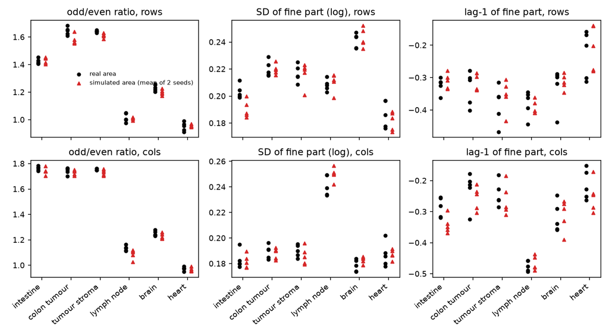

Strisce stimate con lo stesso stimatore di S2.0 sulle 30 aree vere (cerchi neri) e simulate (triangoli rossi, media dei due semi).

**Cosa guardare**: in ogni tessuto i triangoli cadono fra i cerchi; l’unico scarto visibile è la parità delle righe del tumore (il simulatore usa la parità della sezione intera).

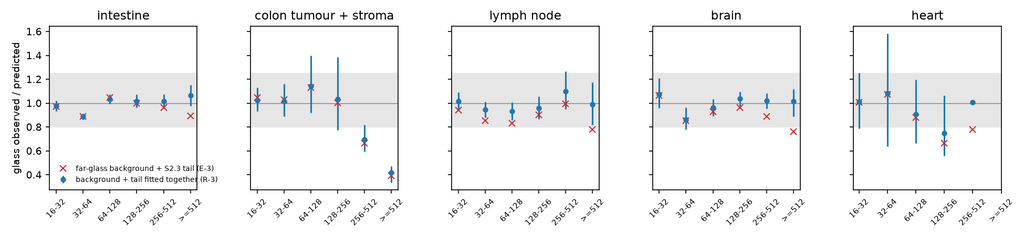

Vetro osservato / previsto per fasce di distanza dal tessuto sulle cinque sezioni intere: croci rosse, fondo del vetro lontano di R5 più la coda di S2.3 (E-3); cerchi blu, fondo e coda adattati insieme (R-3) con intervallo bootstrap. Banda grigia: intervallo di rilevanza [0.8, 1.25].

**Cosa guardare**: dopo R-3 il vetro lontano di intestino, linfonodo e cervello torna nella banda; nel tumore e stroma oltre 256 µm resta sotto.

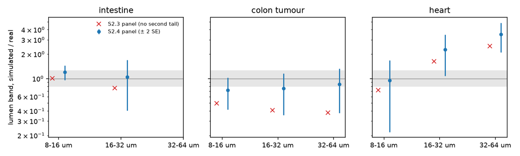

Fasce profonde dei lumi, simulato / vero (scala logaritmica): croci rosse, pannello di S2.3 senza seconda coda; cerchi blu, pannello di S2.4.

**Cosa guardare**: nel tumore del colon la seconda coda porta le fasce da circa 0.4-0.5 a 0.7-0.85; nel cuore (controllo negativo) l’eccesso cresce.

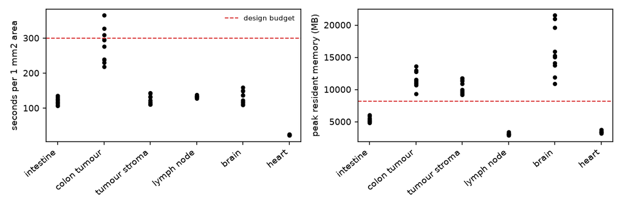

Tempo e picco di memoria per area di 1 mm², catena completa, un processo (server condiviso).

# Controprova e misure

Vedi «Controprove» e «Misure» nella sezione precedente; analisi post hoc:

- **PH-1, memoria per fase** (`tools/S2.4_mem_stages.R`): il picco nasce in `place_and_move_transcripts()` con i trascritti sovra-generati, non nella cattura. Tumore (A2_r1, 39.2 milioni di trascritti generati, M 4.61): 9 824 MB; cervello (A5_r1, 38.8 milioni, M 5.01): 19 848 MB. Nel cervello un’area ha meno di 2 000 cellule e la funzione lavora a blocchi di 2 000 cellule: un solo blocco. Con blocchi di 200 cellule (`tools/S2.4_mem_stages_chunk.R`) lo stesso cervello sta in 5 845 MB e 145 s. Rigenerate con il codice e i semi del pannello, le due aree danno quadratini identici. Il rimedio è un argomento esistente (`chunk_size`), che cambia le estrazioni ma non il modello: lo sceglierà l’orchestratore (BL-227).
- **PH-2, intervalli di R-3**: bootstrap delle tessere (sopra, «Regole»), chiesto dalla revisione avversariale.
- **PH-3, trascritti oltre 280 µm**: con la miscela di R-3, P(raggio > 280 µm) = w₂ (1 + 280/ℓ₂) exp(−280/ℓ₂) più la prima coda: 3.6 % intestino, 2.0 % tumore e stroma, 3.6 % linfonodo, 3.2 % cervello, 2.3 % cuore (la prima coda aggiunge al più lo 0.1 %).

# Revisione avversariale

Tre revisori indipendenti con codice proprio (cartelle `/mnt/micron/geo_spatialtrans/S2.4/review/`).

- **Strisce e lumi** (strisce di 10 aree vere e 20 simulate in intestino e linfonodo, curva di R-1, fasce dei lumi e vuoti in 4 aree): 189 controlli su 201 entro la tolleranza; i 12 restanti spiegati. (i) Il passo 1 di S2.0 (`lag1_repro_hp`) è un rapporto di covarianze fra metà diverse (c₁/c₀), non una correlazione di Pearson come diceva la consegna del revisore; la curva di R-1 usa la stessa definizione. (ii) Lo stimatore di S2.0 toglie le righe con metà sotto 100 quadratini prima della parità e della media mobile (almeno 10 valori su 21) e mette NaN alle righe con meno di 20 quadratini: con queste scelte le 120 quantità per area coincidono entro 0.0024, salvo una riga anomala del revisore in A4_p1. Lo stimatore mette 0 (non NaN) alle righe senza stima: effetto trascurabile, da correggere (BL-228). Con lo stimatore non allineato le righe dell’intestino in P-1 diventerebbero indeterminate invece che confermate (estremo 0.046728 contro 0.046724). (iii) Il riferimento delle fasce dei lumi si somma lumo per lumo (un quadratino vicino a due lumi conta due volte; effetto 0.1 %, uguale per veri e simulati). (iv) R-1: due punti nuovi a ρ −0.45, colonne fuori dalla banda di 2 deviazioni standard per la sola realizzazione (su 400 semi nessuna distorsione). Deviazioni dichiarate dal revisore: A3_r5 al posto di A3_r1 per i lumi dello stroma (A3_r1 non ha lumi interi).
- **Vetro** (R-3 in cervello e tumore e stroma, fasce di P-5, R-2 in tutte le sezioni): R-3 ritrovato (log-verosimiglianza entro 0.05, parametri entro 2.3e-4 relativo, fasce entro 4e-5). Con l’integrazione esatta del nucleo esponenziale sul quadratino (sorgente uniforme invece che al centro, convenzione ereditata da R5 e S2.3) la log-verosimiglianza sale di 1.85 nel cervello e 0.90 nel tumore; parametri e fasce non cambiano oltre 2.3e-4 e 6e-5: spiegato, trascurabile (BL-228). R-3 non aveva intervalli: aggiunti (PH-2). R-2: 20 iterazioni non bastano alla convergenza nel cuore (il verdetto non cambia); il criterio (iv) confronta insiemi annidati e risulta gonfiato; con fasce disgiunte (16-100 µm contro ≥ 100 µm) nel cervello la parte lenta del vetro vicino e del vetro lontano sono quasi scorrelate (0.18), nel tumore la correlazione delle righe non si distingue da un nullo a spostamento circolare (p 0.08), nelle righe dell’intestino la parte lenta correla con la distanza dal tessuto (r 0.47, oltre il nullo). La riproducibilità fra metà della stessa riga non distingue una striscia da un campo liscio nel piano: **la parte lenta trovata sul vetro non è un fattore di riga affidabile**, il che rafforza la decisione di R-2. Deviazioni dichiarate: bootstrap con B = 200 e ℓ₂ su griglia ristretta (intervalli provvisori, sostituiti da PH-2); imbottitura di 1 525 quadratini.
- **Codice e invarianti** (lettura di R/05b4 e delle modifiche di R/05b3, invarianti di A2_r1 e A5_r2, correzione C-1): nessun difetto del codice rispetto al file dello step; .bin rigenerati identici (md5); tutte le identità vere su 614 656 e 608 400 quadratini; atteso dei catturati e del fondo entro 1e-11; parametri di `capture_params()` uguali ai file delle regole (2.1e-15); difetto dei semi riprodotto (fino a 18 deviazioni standard) e assente nelle funzioni corrette (3.6-4.2). Rilievi documentali: decisioni e righe di BIO_REFERENCES ancora da registrare (fatto alla chiusura), voce di BACKLOG sui semi (BL-224), script della verifica dei semi salvato nel repo, documento di progetto da allineare (massimo delle strisce sull’area intera e non per tessera; fondo fuori da `truth$origin`; verità di origine a 8 µm lasciata all’orchestratore). Deviazioni dichiarate: campo della parità del linfonodo controllato solo leggendo il codice; frazioni delle sfocature larga e stretta non ricontrollate.

# Cosa è girato

- Commit dei cancelli `c3181ac`, ok di Luca `045bb47`, codice e regole `83ebaed`, pannello `6724265`; ramo `step2-visium-grid`; R 4.6.2, Python del progetto (`.venv`).
- Funzioni: `R/05b4_capture_and_bin.R` (`capture_params`, `simulate_stripes`, `capture_and_bin`), seconda coda in `R/05b3_place_and_move_transcripts.R`; batteria `R/testing/test_S2.4.R`, `tools/S2.4_test.py`, mutanti `tools/S2.4_mutants.py`.
- Regole: `tools/S2.4_R1_calib.py`, `tools/S2.4_R2_slow.py`, `tools/S2.4_R3_glass.py`, `tools/S2.4_R3_boot.py`; esplorazioni `tools/S2.4_explore.py`, `tools/S2.4_E12_summary.py`.
- Pannello: `tools/S2.4_panel.R` (semi estratti con Mersenne-Twister dal seme 20261114), statistiche `tools/S2.4_explore.py sim`, esiti `tools/S2.4_analysis.py`, `tools/S2.4_verdicts.py`; uscite in `/mnt/micron/geo_spatialtrans/S2.4/`.
- Processi: al più 6 per lavoro; server condiviso con un’altra utente (carico medio da 5 a circa 740). Pannello principale (60 esecuzioni) circa 25 minuti con 6 processi; varianti 15 minuti; R-3 circa 2 minuti per sezione; bootstrap di R-3 circa 1.5 ore.
- md5 dei 362 file letti identici prima e dopo (`results/S2.4/S2.4_md5_before.txt`, `_after.txt`).

## Esplorazioni prima della pre-registrazione

- **E-1** (solo dati veri; `tools/S2.4_explore.py real`, `results/S2.4/S2.4_E1_real.csv`, riepilogo `S2.4_E12_summary.csv`): stimatore delle strisce di S2.0 con la parte fine di PH-5 (10 iterazioni, media mobile su 21 righe o colonne, metà di riga con almeno 100 quadratini di tessuto invece di 200) sulle 30 aree di 1 mm²; tessuto = regioni dello Step 1 al centro allineato del quadratino. Parità dispari/pari delle aree (media per tessuto, righe; colonne): intestino 1.423; 1.763, tumore 1.645; 1.743, stroma 1.642; 1.754, linfonodo 1.015; 1.133, cervello 1.233; 1.250, cuore 0.950; 0.973 (sezioni intere di S2.0: 1.417; 1.750, 1.578; 1.724 per tumore e stroma, 0.996; 1.105, 1.201; 1.231, 0.947; 0.967). Deviazione standard della parte fine 0.178-0.241, passo 1 da −0.21 a −0.48. Differenza massima fra due aree dello stesso tessuto: parità 0.015-0.078, deviazione standard 0.010-0.024, passo 1 0.036-0.153 (intervalli di P-1…P-3). Nessuna riga o colonna a zero UMI nelle aree. Lumi interi di almeno 2 500 µm²: intestino 16, tumore 11, stroma 2, linfonodo 0, cervello 26, cuore 13. Quadratini vuoti in tessuto: 0.07 % (cervello) … 12.7 % (cuore). **Correzione prima dell’uso**: la prima esecuzione contava la parità dal primo quadratino dell’area e non dalla griglia di Space Ranger (parità invertita nelle aree che iniziano su una riga o colonna dispari); corretta (la matrice parte da una riga e una colonna pari), rifatta, versione sbagliata in `/mnt/micron/geo_spatialtrans/S2.4/explore/_superseded_parity/`.
- **E-2** (pannello di S2.3, variante principale: niente strisce, niente seconda coda, fondo di Poisson; `S2.4_E2_sim.csv`): lo stimatore trova parità 1.000-1.001 e deviazione standard della parte fine 0.007-0.025 (contro 0.18-0.24 dei veri): il rumore di fondo dello stimatore è piccolo, P-1 e P-2 avranno potere (anticipa CP-1). Fasce dei lumi, simulato di S2.3 / vero: intestino 8-16 µm 1.01, 16-32 µm 0.77; tumore 8-16 0.50, 16-32 0.41, 32-64 0.39; cuore 8-16 0.72, 16-32 1.63, 32-64 2.47. Quadratini vuoti in tessuto, simulato di S2.3 / vero: da 0.02 (tumore) a 1.1 (cuore).
- **E-3** (sezioni intere; `tools/S2.4_explore.py glass`, `/mnt/micron/geo_spatialtrans/S2.4/explore/glass/`): previsione del vetro con il modello di S2.0 più la seconda coda di DEC-051 e il fondo del vetro lontano di R5 (b_far, vetro a ≥ 300 µm dal tessuto), come nell’adattamento di S2.3. Fra 16 e 256 µm dal tessuto osservato / previsto 0.83-1.13 in tutte le sezioni; **sul vetro lontano la previsione è troppo alta**: a ≥ 300 µm 0.93 (intestino), 0.58 (tumore e stroma), 0.92 (linfonodo), 0.85 (cervello); a ≥ 512 µm 0.89, 0.39, 0.78, 0.76 (nel cuore non c’è vetro oltre 382 µm: 0.78 a 256-512). Il fondo del vetro lontano contiene già una parte della seconda coda: contati insieme, gli stessi trascritti entrano due volte. Rifare il solo fondo con la coda fissa lo abbassa del 6-18 % (b 0.150, 0.185, 0.036, 0.254, 0.097) ma non basta nel tumore (la coda da sola supera il vetro lontano osservato). Fondo e coda adattati insieme sul vetro a 16-500 µm migliorano la verosimiglianza di 451 (tumore, imbottitura larga) … 31 978 unità (cervello); con l’imbottitura della trasformata di S2.3 (600 µm) il fondo va a 0 in quattro sezioni su cinque (intestino, tumore e stroma, linfonodo, cuore) e ℓ₂ supera 1 mm in due (intestino 1 159 µm, linfonodo 1 176 µm; tumore 768, cuore 113); con l’imbottitura di 3 mm il fondo resta a 0 nell’intestino, nel linfonodo e nel cuore (ℓ₂ 1 759, 1 607, 113 µm) e diventa 0.166 nel tumore e stroma (ℓ₂ 469 µm): il fondo nullo non è un effetto del rientro, il fondo e la coda lunga non si separano bene con il vetro di queste sezioni. (Correzione del 2026-11-06, dalla verifica di un revisore: la prima versione diceva «ℓ₂ oltre 1 mm in quattro sezioni su cinque» e attribuiva il fondo nullo al rientro.) Con l’imbottitura di 3 mm (tumore, cervello, cuore; intestino e linfonodo in corso al momento della scrittura) le fasce a coda fissa cambiano al più di 0.02 (tumore e stroma, 64-128 e 128-256 µm; correzione dalla verifica di un revisore, la prima versione diceva 0.01): i valori di DEC-051 dipendono poco dal rientro. Regola R-3.
- **E-4** (solo generatore; `tools/S2.4_explore.py mfac`, `/mnt/micron/geo_spatialtrans/S2.4/explore/E4_mfac.csv`, 20 realizzazioni per tessuto, senza il campo della parità del linfonodo): fattore di sovra-generazione max(c)/media(c), mediana: area di 1 mm² con il margine 4.43 (intestino), 5.07 (tumore e stroma), 4.09 (linfonodo), 4.11 (cervello), 3.15 (cuore); area di cattura intera 5.11, 6.23, 4.74, 4.88, 3.68; tessere di 500 µm con bordo di 280 µm, media 4.20, 4.83, 3.91, 3.87, 3.05. Lavorare a tessere risparmia il 18-22 % dei trascritti generati rispetto al massimo globale, ma è esatto solo se nessun trascritto di una tessera arriva fuori dalla tessera più il bordo: la seconda coda lo viola (vedi BL-209 sotto «Misure»).

## Correzioni prima del calcolo

- **C-1, semi** (trovata dalla prima esecuzione di G-1 e, prima del pannello). Con L’Ecuyer-CMRG inizializzato da `set.seed(seme)`, semi in progressione aritmetica danno sequenze legate linearmente: in alcune posizioni le estrazioni sono quasi uguali fra un seme e il successivo. Verifica (`tools/S2.4_C1_seeds.R`, `results/S2.4/S2.4_C1_seeds.txt`: 8 000 estrazioni di Poisson con medie 0.5 · exp(N(0, 0.4²)), seme 99, su 400 semi; R 4.6.2; la prima versione dello script stava in `/tmp` e il file citava per errore R 4.6.1, corretto dopo la revisione): semi 501-900, scarto massimo 12.4 e 18.3 deviazioni standard (secondo e primo flusso); 400 semi casuali 3.84; Mersenne-Twister con semi consecutivi 3.76 (atteso per 8 000 posizioni: circa 4). Nel test la media resta giusta (osservato / atteso 1.000 nel tessuto, 0.999 nel vetro) ma la varianza fra repliche si gonfia in alcuni quadratini. Correzioni: (a) nelle funzioni di S2.4 il seme si rimescola con Mersenne-Twister prima di inizializzare L’Ecuyer-CMRG (test f5, mutante «seme non rimescolato»); (b) i flussi dei blocchi dell’assottigliamento sono sotto-flussi del flusso 1 (prima il secondo blocco coincideva con il flusso del fondo; mutante «seme ignorato nei blocchi»); (c) nel pannello la formula dei semi pre-registrata (20261114 + 100 000 k + 100 · area + componente, una progressione) è sostituita da semi estratti con Mersenne-Twister dal seme 20261114 in ordine fisso (k × area × componente), anche per le funzioni di S2.2 e S2.3, che restano invariate; (d) nel test e1 le 200 repliche usano semi estratti a caso. Le funzioni di S2.2 e S2.3 inizializzano ancora L’Ecuyer-CMRG con `set.seed` diretto: voce nuova di BACKLOG (rinvio).
- **Test riscritti prima del verdetto di G-1** (stessa intenzione, misura sbagliata): c6 misurava la varianza del campo della parità del linfonodo dentro una finestra di 0.8 mm, più piccola della scala del campo (300 µm), e dava 0.25 per costruzione; ora è la varianza in un punto su 400 realizzazioni (1.03). b2 usa 60 nati nel nucleo su 200 invece di 100 su 200 (con 100 su 200 lo scambio di nucleo e citoplasma non si vede).

## Deviazioni dichiarate

- Correzione C-1 (semi) e test riscritti prima del verdetto di G-1 (sezione «Correzioni prima del calcolo»).
- R-3: la pre-registrazione chiedeva «partenze multiple»; l’adattamento usa la verosimiglianza profilo su ℓ₂ (41 valori da 10 a 5 000 µm, poi ricerca limitata) con (b, w₂) ottimizzati esattamente per ogni ℓ₂: equivalente e più robusto. Intervalli di R-3 con B = 200 (non 2 000) e ℓ₂ su 17 valori: aggiunti dopo la revisione.
- E-3: la frase sul fondo nullo e sulla coda oltre 1 mm era sbagliata nella prima versione (corretta, `1c9dee3`).
- Pannello: la prima esecuzione delle varianti delle controprove si è fermata perché lo script era stato modificato mentre girava (R legge gli script un’espressione alla volta); le 60 esecuzioni principali erano già complete; varianti rilanciate.
- P-5: la fascia 256-512 µm del cuore ha una sola tessera di 300 µm: «non valutabile».

# Appendice: da dove vengono i numeri del riassunto

| frase del riassunto | fonte | valore letto |
| --- | --- | --- |
| strisce: nessuno scarto rilevante | `results/S2.4/S2.4_verdict_counts.csv` (P-1…P-3) | 24 confermate, 12 indeterminate, 0 smentite |
| lo stimatore non trova strisce quando le spegniamo | `results/S2.4/S2.4_CP12.csv` (CP-1) | deviazione standard della parte fine 0.013-0.031; parità entro 1 ± 0.002; 6/6 |
| fondo costante sparisce in intestino, linfonodo e cuore; coda a 1-2 mm (cuore un decimo di mm) | `results/S2.4/S2.4_R3_fits.csv` | b = 0 in A1, A4, A6; ℓ₂ 1 826, 1 575, 113 µm |
| vetro del tumore 7 decimi fra un quarto e mezzo mm, meno della metà oltre | `results/S2.4/S2.4_P5_glass.csv` (A23) | 0.698 (256-512 µm); 0.418 (≥ 512 µm) |
| quattro sezioni su cinque descritte a ogni distanza | `results/S2.4/S2.4_P5_glass.csv` | nessuna fascia smentita in A1, A4, A5, A6 |
| lumi profondi del tumore da circa metà a 7-9 decimi; la coda raddoppia | `S2.4_E12_summary.csv`, `S2.4_predictions.csv` (P-4 A2), `S2.4_CP12.csv` | S2.3: 0.50, 0.41, 0.39; S2.4: 0.72, 0.76, 0.85; con / senza coda 0.046 / 0.024 |
| parte lenta in due sezioni su cinque | `results/S2.4/S2.4_R2_slow.csv` | identificata in A1 e A23 (entrambi gli assi) |
| vuoti: da un decimo a quattro decimi | `results/S2.4/S2.4_predictions.csv` (P-6) | 0.11, 0.10, 0.40 |
| si generano da 3 a 6 volte i trascritti | `results/S2.4/S2.4_measures.csv`, `/mnt/micron/geo_spatialtrans/S2.4/panel/G2.csv` | M 2.91-5.78 (media per tessuto 3.20-5.00) |
| memoria fino a 15-20 GB nel cervello | `S2.4_predictions.csv` (P-7), log di `tools/S2.4_mem_stages.R` | media del cervello 15 888 MB; A5_r1 19 848 MB |
| a blocchi piccoli 6 GB e meno di 3 minuti | log di `tools/S2.4_mem_stages_chunk.R` | 5 845 MB, 145 s |
| una simulazione su 120 a 3.01 | `results/S2.4/S2.4_G2.csv` | max \|z\| 3.011 (A4_f1, senza seconda coda) |
| semi consecutivi legati | `results/S2.4/S2.4_C1_seeds.txt` | 12.4 e 18.3 contro 3.84 (casuali) |
| tempi da 24 s a 280 s | `S2.4_predictions.csv` (P-7) | cuore 23.7 s, tumore 279.6 s |